# CS236605: Deep Learning on Computational Accelerators

### Training

To train such a model, we'll calculate the loss at each time step by comparing the predicted char to the actual char from our label. We can use cross entropy since per char it's similar to a classification problem. We'll then sum the losses over the sequence and back-propagate the gradients though time. Notice that the back-propagation algorithm will "visit" each layer's parameter tensors multiple times, so we'll accumulate gradients in parameters of the blocks. Luckily `autograd` will handle this part for us.

As usual, the first step of training will be to try and **overfit** a large model (many parameters) to a tiny dataset. Again, this is to ensure the model and training code are implemented correctly, i.e. that the model can learn.

For a generative model such as this, overfitting is slightly trickier than for for classification. What we'll aim to do is to get our model to **memorize** a specific sequence of chars, so that when given the first char in the sequence it will immediately spit out the rest of the sequence verbatim.

Let's create a tiny dataset to memorize.

```python
# Pick a tiny subset of the dataset
subset_start, subset_end = 1001, 1005
ds_corpus_ss = torch.utils.data.Subset(ds_corpus, range(subset_start, subset_end))
dl_corpus_ss = torch.utils.data.DataLoader(ds_corpus_ss, batch_size=1, shuffle=False)

# Convert subset to text
subset_text = ''
for i in range(subset_end - subset_start):
    subset_text += unembed(ds_corpus_ss[i][0])
print(f'Text to "memorize":\n\n{subset_text}')
```

```
Text to "memorize":

TRAM. What would you have?
  HELENA. Something; and scarce so much; nothing, indeed.
    I would not tell you what I would, my lord.
    Faith, yes:
    Strangers and foes do sunder and not kiss.
  BERTRAM. I pray you, stay not, but in haste to horse.
  HE
```

Now let's implement the first part of our training code.

**TODO**: Implement the `train_epoch()` and `train_batch()` methods of the `RNNTrainer` class in the `hw3/training.py` module. Note: Think about how to correctly handle the hidden state of the model between batches and epochs (for this specific task, i.e. text generation).

```python
import torch.nn as nn
import torch.optim as optim
from hw3.training import RNNTrainer

torch.manual_seed(42)

lr = 0.01
num_epochs = 500

in_dim = vocab_len
h_dim = 128
n_layers = 2
loss_fn = nn.CrossEntropyLoss()
model = charnn.MultilayerGRU(in_dim, h_dim, out_dim=in_dim, n_layers=n_layers).to(device)
optimizer = optim.Adam(model.parameters(), lr=lr)
trainer = RNNTrainer(model, loss_fn, optimizer, device)

for epoch in range(num_epochs):
    epoch_result = trainer.train_epoch(dl_corpus_ss, verbose=False)

    # Every X epochs, we'll generate a sequence starting from the first char in the first sequence
    # to visualize how/if/what the model is learning.
    if epoch == 0 or (epoch+1) % 25 == 0:
        avg_loss = np.mean(epoch_result.losses)
        accuracy = np.mean(epoch_result.accuracy)
        print(f'\nEpoch #{epoch+1}: Avg. loss = {avg_loss:.3f}, Accuracy = {accuracy:.2f}%')

        generated_sequence = charnn.generate_from_model(model, subset_text[0],
                                                        seq_len*(subset_end-subset_start),
                                                        (char_to_idx,idx_to_char), T=1)
        # Stop if we've successfully memorized the small dataset.
        print(generated_sequence)
        if generated_sequence == subset_text:
            print(f'Stopped on Epoch {epoch + 1}')
            break

# Test successful overfitting
test.assertGreater(epoch_result.accuracy, 99)
test.assertEqual(generated_sequence, subset_text)
```

```
Epoch #1: Avg. loss = 4.014, Accuracy = 17.58%
TkDd aooo etIh os o tos.saodsrutdcn o ,d osas  Mektsoho ea ee
g   u   ygy  do nos oaot e m soaoit oL
nooe ett tEe.y  ntoe o
euils nd syaoa edeeeg ,eaa enrUa nh watfea tw aao
 tty  e ut h.toa eta iaaI so t ou nreLaoT s te ttdiato   yuuoa  tat2ounauttras aao

Epoch #25: Avg. loss = 0.204, Accuracy = 96.88%
TRRMM. What wthiv;d  o  uthing, indeed.
    I would not kiss.
  HELERAM. I I youhasee.
  HELaRT.A  HSrav; soese .
  HELERAM. So etranger; and not kiss.
d.
    Faith, yes:
     Fatrees d BERTAA. I pray you, stay not, bunohstaste to hand soesd.
    Faith, te

Epoch #50: Avg. loss = 0.008, Accuracy = 100.00%
TRAM. What would you have?
  HELENA. Something; and scarce so much; nothing, indeed.
    I would not tell you what I would, my lord.
    Faith, yes:
    Strangers and foes d  ould not kiss.
  BERTRAM. I pray you, stay not, but in haste to horse.
  HELENA.

Epoch #75: Avg. loss = 0.004, Accuracy = 100.00%
TRAM. What uo horse?
  HELaNA. I pray you have?
  HELENA. wou thand scarce so much; nothing, indeed.
    I would not tell you what I would, my lord.
    Faith, yes:
    I would not tell you what I would, my lord.
    Faith, yes:
    Strangers and foes do s

Epoch #100: Avg. loss = 0.002, Accuracy = 100.00%
TRAM. What would, my lord.
    Faith, yes:
    Strangers and foes do sunder and not kiss.
  BERTRAM. I pray you, stay not, but in haste to horse.
  HELERAM. pELyTRAM. I pray you, stay not, but in haste to horse.
  HELENA. Something; and scarce so much; not

Epoch #125: Avg. loss = 0.001, Accuracy = 100.00%
TRAM. What would you have?
  HELENA. Something; and scarce so much; nothing, indeed.
    I would not tell you what I would, my lord.
    Faith, yes:
    Strangers and foes do sunder and not kiss.
  BERTRAM. I pray you, stay not, but in haste to horse.
  HE
Stopped on Epoch 125
```

OK, so training works - we can memorize a short sequence. Next on the agenda is to split our full dataset into a training and test sets of batched sequences.

```python
# Full dataset definition
vocab_len = len(char_to_idx)
seq_len = 64
batch_size = 256
train_test_ratio = 0.9
num_samples = (len(corpus) - 1) // seq_len
num_train = int(train_test_ratio * num_samples)

samples, labels = charnn.chars_to_labelled_samples(corpus, char_to_idx, seq_len, device)

ds_train = torch.utils.data.TensorDataset(samples[:num_train], labels[:num_train])
dl_train = torch.utils.data.DataLoader(ds_train, batch_size=batch_size, shuffle=False, drop_last=True)

ds_test = torch.utils.data.TensorDataset(samples[num_train:], labels[num_train:])
dl_test = torch.utils.data.DataLoader(ds_test, batch_size=batch_size, shuffle=False, drop_last=True)

print(f'Train: {len(dl_train):3d} batches, {len(dl_train)*batch_size*seq_len:7d} chars')
print(f'Test:  {len(dl_test):3d} batches, {len(dl_test)*batch_size*seq_len:7d} chars')
```

```
Train: 348 batches, 5701632 chars
Test:   38 batches,  622592 chars
```

We'll now train a much larger model on our large dataset. You'll need a **GPU** for this part.

The code blocks below will train the model and save checkpoints containing the training state and the best model parameters to a file. This allows you to stop training and resume it later from where you left.

Note that you can use the `main.py` script provided within the assignment folder to run this notebook from the command line as if it were a python script by using the `run-nb` subcommand. This allows you to train your model using this notebook without starting jupyter. You can combine this with `srun` or `sbatch` to run the notebook with a GPU on the course servers.

```python
# Full training definition
lr = 0.001
num_epochs = 50

in_dim = out_dim = vocab_len
hidden_dim = 512
n_layers = 3
dropout = 0.5
checkpoint_file = 'checkpoints/rnn'
max_batches = 300
early_stopping = 5

model = charnn.MultilayerGRU(in_dim, hidden_dim, out_dim, n_layers, dropout)
loss_fn = nn.CrossEntropyLoss()
optimizer = optim.Adam(model.parameters(), lr=lr)
scheduler = optim.lr_scheduler.ReduceLROnPlateau(optimizer, mode='max', factor=0.5, patience=2, verbose=True)
trainer = RNNTrainer(model, loss_fn, optimizer, device)
```

**TODO**:

- Implement the `fit()` method of the `Trainer` class. You can reuse the implementation from HW2, but make sure to implement early stopping and checkpoints.
- Implement the `test_epoch()` and `test_batch()` methods of the `RNNTrainer` class in the `hw3/training.py` module.
- Run the following block to train.

```python
from cs236605.plot import plot_fit

def post_epoch_fn(epoch, test_res, train_res, verbose):
    # Update learning rate
    scheduler.step(test_res.accuracy)
    # Sample from model to show progress
    if verbose:
        start_seq = "ACT I."
        generated_sequence = charnn.generate_from_model(
            model, start_seq, 100, (char_to_idx,idx_to_char), T=0.5
        )
        print(generated_sequence)

# Train, unless final checkpoint is found
checkpoint_file_final = f'{checkpoint_file}_final.pt'
if os.path.isfile(checkpoint_file_final):
    print(f'*** Loading final checkpoint file {checkpoint_file_final} instead of training')
    saved_state = torch.load(checkpoint_file_final, map_location=device)
    model.load_state_dict(saved_state['model_state'])
else:
    try:
        # Print pre-training sampling
        print(charnn.generate_from_model(model, "ACT I.", 100, (char_to_idx,idx_to_char), T=0.5))

        fit_res = trainer.fit(dl_train, dl_test, num_epochs, max_batches=max_batches,
                              post_epoch_fn=post_epoch_fn, #early_stopping=early_stopping,
                              checkpoints=checkpoint_file, print_every=1)

        fig, axes = plot_fit(fit_res)
    except KeyboardInterrupt as e:
        print('\n *** Training interrupted by user')
```

```
ACT I.LPgk?G4:w,tVL:Z)KAq5V(dXS0sx
LEz]c:RvFN lQZJx!pe,Vp4.nAFPX0jB!qaWls&j"8B655uQw&n4
Wem!DJ3Nn6B8
--- EPOCH 1/50 ---
train_batch (Avg. Loss 2.299, Accuracy 37.6): 100%|██████████| 300/300 [01:06<00:00,  4.50it/s]
test_batch (Avg. Loss 2.248, Accuracy 38.2): 100%|██████████| 38/38 [00:02<00:00, 13.01it/s]
*** Saved checkpoint checkpoints/rnn.pt at epoch 1
ACT I. I mary be not sain my love in as a mastesst and not so me the feath my me say his all with me
--- EPOCH 2/50 ---
train_batch (Avg. Loss 1.812, Accuracy 47.8): 100%|██████████| 300/300 [01:07<00:00,  4.57it/s]
test_batch (Avg. Loss 2.080, Accuracy 43.1): 100%|██████████| 38/38 [00:02<00:00, 12.76it/s]
*** Saved checkpoint checkpoints/rnn.pt at epoch 2
ACT I. I that I may sech you for my fear and make the be and dead.
    I what me the sent and will b
--- EPOCH 3/50 ---
train_batch (Avg. Loss 1.680, Accuracy 51.2): 100%|██████████| 300/300 [01:06<00:00,  4.57it/s]
test_batch (Avg. Loss 1.994, Accuracy 45.6): 100%|██████████| 38/38 [00:02<00:00, 13.11it/s]
*** Saved checkpoint checkpoints/rnn.pt at epoch 3
ACT I. I have not shall not do not be my death.
    I have not in the fair of good fair and great of
--- EPOCH 4/50 ---
train_batch (Avg. Loss 1.603, Accuracy 53.3): 100%|██████████| 300/300 [01:09<00:00,  4.58it/s]
test_batch (Avg. Loss 1.939, Accuracy 47.2): 100%|██████████| 38/38 [00:02<00:00, 13.14it/s]
*** Saved checkpoint checkpoints/rnn.pt at epoch 4
ACT I.
  ALIVEL. [Aside] I see the Amen's seach a bastard of with the sent and advil him.

--- EPOCH 5/50 ---
train_batch (Avg. Loss 1.551, Accuracy 54.7): 100%|██████████| 300/300 [01:08<00:00,  4.56it/s]
test_batch (Avg. Loss 1.903, Accuracy 48.3): 100%|██████████| 38/38 [00:02<00:00, 13.15it/s]
*** Saved checkpoint checkpoints/rnn.pt at epoch 5
ACT I. So, to be my lord.
  TROILUS. I do not we will not the knew come to the gracious show me.

--- EPOCH 6/50 ---
train_batch (Avg. Loss 1.514, Accuracy 55.8): 100%|██████████| 300/300 [01:06<00:00,  4.55it/s]
test_batch (Avg. Loss 1.875, Accuracy 49.0): 100%|██████████| 38/38 [00:02<00:00, 13.11it/s]
*** Saved checkpoint checkpoints/rnn.pt at epoch 6
ACT I. O must not fall it.
  CRESSIDA. A praise your sweet talence, but that you shall leave and act
```

[output cut: 58 more lines]

```
London. I will not leave you for your noble Archmis' malice,
    That she should be
--- EPOCH 15/50 ---
train_batch (Avg. Loss 1.392, Accuracy 59.0): 100%|██████████| 300/300 [01:07<00:00,  4.53it/s]
test_batch (Avg. Loss 1.802, Accuracy 51.5): 100%|██████████| 38/38 [00:02<00:00, 13.04it/s]
*** Saved checkpoint checkpoints/rnn.pt at epoch 15
ACT I. A good and a dog on the patience
    That shall be a little state of the reason in such a fai
--- EPOCH 16/50 ---
train_batch (Avg. Loss 1.385, Accuracy 59.1): 100%|██████████| 300/300 [01:08<00:00,  4.17it/s]
test_batch (Avg. Loss 1.801, Accuracy 51.6): 100%|██████████| 38/38 [00:03<00:00, 12.96it/s]
*** Saved checkpoint checkpoints/rnn.pt at epoch 16
ACT I. SCENE I.
The part of the top. He hath the reason of our tale of blood. I have still expect th
--- EPOCH 17/50 ---
```

### Generating a work of art

Armed with our fully trained model, let's generate the next Hamlet! You should experiment with modifying the sampling temperature and see what happens.

**TODO**: Specify the generation parameters in the `part1_generation_params()` function within the `hw3/answers.py` module.

```python
import hw3.answers

start_seq, temperature = hw3.answers.part1_generation_params()

generated_sequence = charnn.generate_from_model(
    model, start_seq, 10000, (char_to_idx,idx_to_char), T=temperature
)

print(generated_sequence)
```

```
ACT I. SCENE I.
The joy.
  CRESSIDA. I would you see my part in our fool.
  PAROLLES. I do beseech you, what art thou? What is the matter?
  ANTONY. But there's a good father of a fair content,
    Poor and the first that phosich every way to have him shall not fly.
  AGUECHEEK. Sir, I do excuse you in the pride. I will not be a better soul.
    He doth not come for a living sport to see the palace
    And such a fit of it is to be so;
    He is not so in the prince of my mother's word.
    O, he cannot be a fair father to our prince,
    And with a birth that the base part of the earth
    As in the stone a fool to be my sword a flower
    That he was made a shape and poor father's son.
    What should I be a warlike thank you?
  SIR TOBY. What is thy note?
  CRESSIDA. I thank your Grace in him. I warrant you. I am a time for the streets of the time
    That knows not that the mean to follow me to be a devil sir.
    Come, then, if thou dost not stay to thee.
                                                                                                                                                                                                                                                                                                            …

  CRESSIDA. I know not what comes the gods stay a deed of the lady.
    And therefore then I am a sufferance and the town,
    See how the particular and a good we do beseech you, sir, if it come to the maid.
    Go with me to the patience; I'll go see thee, sir, that I have stock'd the heavens of my sight.
  CRESSIDA. Why, what a truth is this in my heart?
  COUNTESS. I will not shall think it is a royal state, you are not heard,
    Which we may say each with the selt in the night.
    I will not be a contempt of heaven, I'll be so a man, and my prodigal pillow should find the devil and thy sons,
    Who knows the deed of strangers fall; and, by your father's mind that you shall see the fair and more than my company.
    He is a word in this matter. I will assure you, that you shall be the man.
  MARCUS. The beast is not to be a single sea,
    And therefore I myself may see it in the wind and town;
    But I am the less that he shall see thee title.
                                                                                                                                                                                                                                                                                                            …

  CLEOPATRA. I know not, sir, I pray you; we are made of love,
    By the man that may give me live.
  PAROLLES. Why, how now, sir, you say 'tis the man, sir, it is not so in arms and see
    Her sons and manners of the people for the pale and deeds.
```

[output cut: 33 more lines]

```
  CRESSIDA. I fear you may have a banquet that hath not so one of your brother's daughter,
    That thou mayst not be sworn to do the first of his excellent man.
  CRESSIDA. Why, then I know not, sir.
  AJAX. I am a sister to a better soul to her that she is so such a man.
    I will not be to straight to the person of the dead!
    Let me shake the palace be the prince, and beggars do stand the boy.
    Exeunt ARIEL, and BASSIANUS

  AGUECHEEK. I may not stay the sea?
  MARCUS. What says he now? He was a promise all the rest of his heart;
    And therefore to the great desire of it.
  SIR TOBY. I will not see you shall hold the way of heart and madness.
    What hath he seen the base and boy of mother is the company of the man's brother Timon's shame,
    That will not be a fool to be a charm as deed as ever says the way of his company.
    Come, you are
```

## Questions

**TODO** Answer the following questions. Write your answers in the appropriate variables in the module `hw3/answers.py`.

```python
from cs236605.answers import display_answer
import hw3.answers
```

### Question 1

Why do we split the corpus into sequences instead of training on the whole text?

```python
display_answer(hw3.answers.part1_q1)
```

We split the data because we want to limit the BPTT process. The whole text is huge, and this means that backwards through time will take too long to calculate. Batches, with detaching of hidden state between them, allow us to include less modules in the backward propogation process. Even if we do train on the whole text, it wouldn't change much due to vanishing gradients.

### Question 2

How is it possible that the generated text clearly shows memory longer than the sequence length?

```python
display_answer(hw3.answers.part1_q2)
```

As part of the training process, we keep the hidden state between batches (and apply detach() on it so it won't be included in the BPTT). This does contribute to longer memory, without having to pay the price of backpropogating too far back.

### Question 3

Why are we not shuffling the order of batches when training?

```python
display_answer(hw3.answers.part1_q3)
```

We don't shuffle because of of the importance of context. We want to make sure that each batch has the memory of the batch before (except the first, which is negligible compared to the batch number), so we don't learn half words or broken phrases. We also would like to learn in a more macro level, the parts of the text and not just what character comes after which one.

### Question 4

1. Why do we lower the temperature for sampling (compared to the default of $1.0$ when training)?
2. What happens when the temperature is very high and why?
3. What happens when the temperature is very low and why?

```python
display_answer(hw3.answers.part1_q4)
```

1. Lowering the temperature greatly affect the variance of the output, which results in a more 'spiky' probabilities, for fewer characters. This ensures us more certainty of the selection of the characters. This is good for sampling because we want to have text that resembles the source. While training, we prefer higher temperatures, which result in a more exploring nature. This variance allows us to better update the weights.

2. When the temperature is very high we will see uniform distribution between the characters, which will result in a random sequence. This is because we make the differences between values smaller, which results in similar values when softmaxing.

3. When the temperature is ver low the opposite happens. greater differences, while the softmax function is exponential result in very 'spiky' nature, where the smaller values get smaller, and the larger values get larger. This decreases the variance and increase the probability of choosing from a small subset.

$$ \newcommand{\mat}[1]{\boldsymbol {#1}} \newcommand{\mattr}[1]{\boldsymbol {#1}^\top} \newcommand{\matinv}[1]{\boldsymbol {#1}^{-1}} \newcommand{\vec}[1]{\boldsymbol {#1}} \newcommand{\vectr}[1]{\boldsymbol {#1}^\top} \newcommand{\rvar}[1]{\mathrm {#1}} \newcommand{\rvec}[1]{\boldsymbol{\mathrm{#1}}} \newcommand{\diag}{\mathop{\mathrm {diag}}} \newcommand{\set}[1]{\mathbb {#1}} \newcommand{\norm}[1]{\left\lVert#1\right\rVert} \newcommand{\pderiv}[2]{\frac{\partial #1}{\partial #2}} \newcommand{\bm}[1]{{\bf #1}} \newcommand{\bb}[1]{\bm{\mathrm{#1}}} $$

# Part 2: Variational Autoencoder

In this part we will learn to generate new data using a special type of autoencoder model which allows us to sample from it's latent space. We'll implement and train a VAE and use it to generate new images.

```python
import unittest
import os
import sys
import pathlib
import urllib
import shutil
import re
import zipfile

import numpy as np
import torch
import matplotlib.pyplot as plt

%load_ext autoreload
%autoreload 2

test = unittest.TestCase()
plt.rcParams.update({'font.size': 12})
device = torch.device('cuda' if torch.cuda.is_available() else 'cpu')
print('Using device:', device)
```

```
Using device: cuda
```

### Obtaining the dataset

Let's begin by downloading a dataset of images that we want to learn to generate. We'll use the [Labeled Faces in the Wild](http://vis-www.cs.umass.edu/lfw/) (LFW) dataset which contains many labels faces of famous individuals.

We're going to train our generative model to generate a specific face, not just any face. Since the person with the most images in this dataset is former president George W. Bush, we'll set out to train a Bush Generator :)

However, if you feel adventurous and/or prefer to generate something else, feel free to edit the `PART2_CUSTOM_DATA_URL` variable in `hw3/answers.py`.

```python
import cs236605.plot as plot
import cs236605.download
from hw3.answers import PART2_CUSTOM_DATA_URL as CUSTOM_DATA_URL

DATA_DIR = pathlib.Path.home().joinpath('.pytorch-datasets')
if CUSTOM_DATA_URL is None:
    DATA_URL = 'http://vis-www.cs.umass.edu/lfw/lfw-bush.zip'
else:
    DATA_URL = CUSTOM_DATA_URL

_, dataset_dir = cs236605.download.download_data(out_path=DATA_DIR, url=DATA_URL, extract=True, force=False)
```

[output not shown]

Create a `Dataset` object that will load the extraced images:

```python
import torchvision.transforms as T
from torchvision.datasets import ImageFolder

im_size = 64
tf = T.Compose([
    # Resize to constant spatial dimensions
    T.Resize((im_size, im_size)),
    # PIL.Image -> torch.Tensor
    T.ToTensor(),
    # Dynamic range [0,1] -> [-1, 1]
    T.Normalize(mean=(.5,.5,.5), std=(.5,.5,.5)),
])

ds_gwb = ImageFolder(os.path.dirname(dataset_dir), tf)
```

OK, let's see what we got. You can run the following block multiple times to display a random subset of images from the dataset.

```
Found 530 images in dataset folder.
```

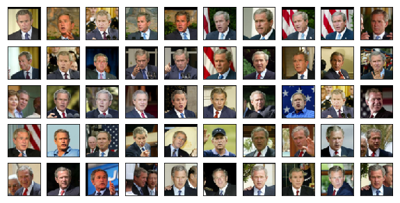

```python
_ = plot.dataset_first_n(ds_gwb, 50, figsize=(10,5), nrows=5)
print(f'Found {len(ds_gwb)} images in dataset folder.')
```

```python
x0, y0 = ds_gwb[0]
x0 = x0.unsqueeze(0).to(device)
print(x0.shape)

test.assertSequenceEqual(x0.shape, (1, 3, im_size, im_size))
```

```
torch.Size([1, 3, 64, 64])
```

## The Variational Autoencoder

An autoencoder is a model which learns a representation of data in an **unsupervised** fashion (i.e without any labels). Recall it's general form from the lecture:

[figure not shown]

An autoencoder maps an instance $\bb{x}$ to a **latent-space** representation $\bb{z}$. It has an encoder part, $\Phi_{\bb{\alpha}}(\bb{x})$ (a neural net with parameters $\bb{\alpha}$) and a decoder part, $\Psi_{\bb{\beta}}(\bb{z})$ (a neural net with parameters $\bb{\beta}$).

While autoencoders can learn useful representations, generally it's hard to use them as generative models because there's no distribution we can sample from in the latent space. In other words, we have no way to choose a point $\bb{z}$ in the latent space such that $\Psi(\bb{z})$ will end up on the data manifold in the instance space.

[figure not shown]

The variational autoencoder (VAE), first proposed by [Kingma and Welling](https://arxiv.org/pdf/1312.6114.pdf), addresses this issue by taking a probabilistic perspective. Briefly, a VAE model can be described as follows.

We define, in Baysean terminology,

- The **prior** distribution $p(\bb{Z})$ on points in the latent space.
- The **likelihood** distribution of a sample $\bb{X}$ given a latent-space representation: $p(\bb{X}|\bb{Z})$.
- The **posterior** distribution of points in the latent spaces given a specific instance: $p(\bb{Z}|\bb{X})$.
- The **evidence** distribution $p(\bb{X})$ which is the distribution of the instance space due to the generative process.

To create our variational **decoder** we'll further specify:

- A parametric likelihood distribution, $p _{\bb{\beta}}(\bb{X} | \bb{z}) = \mathcal{N}( \Psi _{\bb{\beta}}(\bb{z}) , \sigma^2 \bb{I} )$. The interpretation is that given a latent $\bb{z}$, we map it to a point normally distributed around the point calculated by our decoder neural network. Note that here $\sigma^2$ is a hyperparameter while $\vec{\beta}$ represents the network parameters.
- A fixed latent-space prior distribution of $p(\bb{Z}) = \mathcal{N}(\bb{0},\bb{I})$.

This setting allows us to generate a new instance $\bb{x}$ by sampling $\bb{z}$ from the multivariate normal distribution, obtaining the instance-space mean $\Psi _{\bb{\beta}}(\bb{z})$ using our decoder network, and then sampling $\bb{x}$ from $\mathcal{N}( \Psi _{\bb{\beta}}(\bb{z}) , \sigma^2 \bb{I} )$.

Our variational **encoder** will approximate the posterior with a parametric distribution $q _{\bb{\alpha}}(\bb{Z} | \bb{x}) \sim \mathcal{N}( \bb{\mu} _{\bb{\alpha}}(\bb{x}), \mathrm{diag}\{ \bb{\sigma}^2_{\bb{\alpha}}(\bb{x}) \} )$. The interpretation is that our encoder neural network, $\Phi_{\vec{\alpha}}(\bb{x})$, calculates the mean and variance of the posterior distribution, and samples $\bb{z}$ based on them. An important nuance here is that our network can't contain any stochastic elements that depend on the model parameters, otherwise we won't be able to back-propagate to those parameters. So sampling $\bb{z}$ from $\mathcal{N}( \bb{\mu} _{\bb{\alpha}}(\bb{x}), \mathrm{diag}\{ \bb{\sigma}^2_{\bb{\alpha}}(\bb{x}) \} )$ is not an option. The solution is to use what's known as the **reparametrization trick**: sample from an isotropic Gaussian, i.e. $\bb{u}\sim\mathcal{N}(\bb{0},\bb{I})$ (which doesn't depend on trainable parameters), and calculate the latent representation as $\bb{z} = \bb{\mu} _{\bb{\alpha}}(\bb{x}) + \bb{u}\odot\bb{\sigma}^2_{\bb{\alpha}}(\bb{x})$.

To train a VAE model, we would like to maximize the evidence, $p(\bb{X})$, because $ p(\bb{X}) = \int p(\bb{X}|{\bb{z}})p(\bb{z})d\bb{z} $ thus maximizing the likelihood of generated instances from over the entire latent space.

The **VAE loss** can therefore be stated as minimizing $\mathcal{L} = -\mathbb{E}_{\bb{x}} \log p(\bb{X})$. As we saw in the lecture, this expectation is intractable, but we can obtain a lower-bound for $p(\bb{X})$ (the evidence lower bound, "ELBO"):

$$ \log p(\bb{X}) \ge \mathbb{E} _{\bb{z} \sim q _{\bb{\alpha}} }( \log p _{\bb{\beta}}(\bb{X} | \bb{z}) ) - \mathcal{D} _{\mathrm{KL}}\left(q _{\bb{\alpha}}(\bb{Z} | \bb{X})\,\left\|\, p(\bb{Z} )\right.\right) $$

where $ \mathcal{D} _{\mathrm{KL}}(q\left\|\right.p) = \mathbb{E}_{\bb{z}\sim q}\left[ \log \frac{q(\bb{Z})}{p(\bb{Z})} \right] $ is the Kullback-Liebler divergence, which can be interpreted as the information gained by using the posterior $q(\bb{Z|X})$ instead of the prior distribution $p(\bb{Z})$.

By remembering that the likelihood is a Gaussian distribution with a diagonal covariance and by applying the reparametrization trick, we can write the above as

$$ \mathcal{L}(\vec{\alpha},\vec{\beta}) = \mathbb{E} _{\bb{x}} \left[ \mathbb{E} _{\bb{z} \sim q _{\bb{\alpha}} } \left[ \frac{1}{2\sigma^2}\left\| \bb{x}- \Psi _{\bb{\beta}}\left( \bb{\mu} _{\bb{\alpha}}(\bb{x}) + \bb{\Sigma}^{\frac{1}{2}} _{\bb{\alpha}}(\bb{x}) \bb{u} \right) \right\| _2^2 \right] + \mathcal{D} _{\mathrm{KL}}\left(q _{\bb{\alpha}}(\bb{Z} | \bb{x})\,\left\|\, p(\bb{Z} )\right.\right) \right]. $$

### Model Implementation

Obviously our model will have two parts, an encoder and a decoder. Since we're working with images, we'll implement both as deep **convolutional** networks, where the decoder is a "mirror image" of the encoder implemented with adjoint (AKA transposed) convolutions. Between the encoder CNN and the decoder CNN we'll implement the sampling from the parametric posterior approximator $q_{\bb{\alpha}}(\bb{Z}|\bb{x})$ to make it a VAE model and not just a regular autoencoder (of course, this is not yet enough to create a VAE, since we also need a special loss function which we'll get to later).

First let's implement just the CNN part of the Encoder network (this is not the full $\Phi_{\vec{\alpha}}(\bb{x})$ yet). As usual, it should take an input image and map to a activation volume of a specified depth. We'll consider this volume as the features we extract from the input image. Later we'll use these to create the latent space representation of the input. which will be our latent space representation.

**TODO**: Implement the `EncoderCNN` class in the `hw3/autoencoder.py` module. Implement any CNN architecture you like. If you need "architecture inspiration" you can see e.g. [this](https://arxiv.org/pdf/1512.09300.pdf) or [this](https://arxiv.org/pdf/1511.06434.pdf) paper.

```python
import hw3.autoencoder as autoencoder

in_channels = 3
out_channels = 1024
encoder_cnn = autoencoder.EncoderCNN(in_channels, out_channels).to(device)
print(encoder_cnn)

h = encoder_cnn(x0)
print(h.shape)

test.assertEqual(h.dim(), 4)
test.assertSequenceEqual(h.shape[0:2], (1, out_channels))
```

```
EncoderCNN(
  (cnn): Sequential(
    (0): Conv2d(3, 180, kernel_size=(6, 6), stride=(2, 2), padding=(1, 1))
    (1): ReLU()
    (2): BatchNorm2d(180, eps=1e-05, momentum=0.1, affine=True, track_running_stats=True)
    (3): Conv2d(180, 360, kernel_size=(3, 3), stride=(2, 2))
    (4): BatchNorm2d(360, eps=1e-05, momentum=0.1, affine=True, track_running_stats=True)
    (5): ReLU()
    (6): Conv2d(360, 540, kernel_size=(3, 3), stride=(3, 3))
    (7): BatchNorm2d(540, eps=1e-05, momentum=0.1, affine=True, track_running_stats=True)
    (8): ReLU()
    (9): Conv2d(540, 1024, kernel_size=(2, 2), stride=(1, 1))
    (10): BatchNorm2d(1024, eps=1e-05, momentum=0.1, affine=True, track_running_stats=True)
    (11): ReLU()
  )
)
torch.Size([1, 1024, 4, 4])
```

Now let's implement the CNN part of the Decoder. Again this is not yet the full $\Psi _{\bb{\beta}}(\bb{z})$. It should take an activation volume produced by your `EncoderCNN` and output an image of the same dimensions as the Encoder's input was. This should be a CNN which is a "mirror image" of the the Encoder. For example, replace convolutions with transposed convolutions, downsampling with up-sampling etc. Consult the documentation of [ConvTranspose2D](https://pytorch.org/docs/0.4.1/nn.html#convtranspose2d) to figure out how to reverse your convolutional layers in terms of input and output dimensions.

**TODO**: Implement the `DecoderCNN` class in the `hw3/autoencoder.py` module.

```python
decoder_cnn = autoencoder.DecoderCNN(in_channels=out_channels, out_channels=in_channels).to(device)
print(decoder_cnn)
x0r = decoder_cnn(h)
print(x0r.shape)

# test.assertEqual(x0.shape, x0r.shape)

# Should look like colored noise
# T.functional.to_pil_image(x0r[0].cpu().detach())
```

```
DecoderCNN(
  (cnn): Sequential(
    (0): ReLU()
    (1): BatchNorm2d(1024, eps=1e-05, momentum=0.1, affine=True, track_running_stats=True)
    (2): ConvTranspose2d(1024, 540, kernel_size=(2, 2), stride=(1, 1))
    (3): ReLU()
    (4): BatchNorm2d(540, eps=1e-05, momentum=0.1, affine=True, track_running_stats=True)
    (5): ConvTranspose2d(540, 360, kernel_size=(3, 3), stride=(3, 3))
    (6): ReLU()
    (7): BatchNorm2d(360, eps=1e-05, momentum=0.1, affine=True, track_running_stats=True)
    (8): ConvTranspose2d(360, 180, kernel_size=(3, 3), stride=(2, 2))
    (9): ReLU()
    (10): BatchNorm2d(180, eps=1e-05, momentum=0.1, affine=True, track_running_stats=True)
    (11): ConvTranspose2d(180, 3, kernel_size=(6, 6), stride=(2, 2), padding=(1, 1))
    (12): BatchNorm2d(3, eps=1e-05, momentum=0.1, affine=True, track_running_stats=True)
  )
)
torch.Size([1, 3, 64, 64])
```

Let's now implement the full VAE Encoder, $\Phi_{\vec{\alpha}}(\vec{x})$. It will work as follows:

Note that we model the **log** of the variance, not the actual variance. The reason is that the log is easier to optimize, since (a) It doesn't have to be positive, and (b) it has a much larger dynamic range. The above formulation is proposed in appendix C of the [VAE paper](https://arxiv.org/pdf/1312.6114.pdf).

**TODO**: Implement the `encode()` method in the `VAE` class within the `hw3/autoencoder.py` module. You'll also need to define your parameters in `__init__()`.

```
VAE(
  (features_encoder): EncoderCNN(
    (cnn): Sequential(
      (0): Conv2d(3, 180, kernel_size=(6, 6), stride=(2, 2), padding=(1, 1))
      (1): ReLU()
      (2): BatchNorm2d(180, eps=1e-05, momentum=0.1, affine=True, track_running_stats=True)
      (3): Conv2d(180, 360, kernel_size=(3, 3), stride=(2, 2))
      (4): BatchNorm2d(360, eps=1e-05, momentum=0.1, affine=True, track_running_stats=True)
      (5): ReLU()
      (6): Conv2d(360, 540, kernel_size=(3, 3), stride=(3, 3))
      (7): BatchNorm2d(540, eps=1e-05, momentum=0.1, affine=True, track_running_stats=True)
      (8): ReLU()
      (9): Conv2d(540, 1024, kernel_size=(2, 2), stride=(1, 1))
      (10): BatchNorm2d(1024, eps=1e-05, momentum=0.1, affine=True, track_running_stats=True)
      (11): ReLU()
    )
  )
  (features_decoder): DecoderCNN(
    (cnn): Sequential(
      (0): ReLU()
      (1): BatchNorm2d(1024, eps=1e-05, momentum=0.1, affine=True, track_running_stats=True)
      (2): ConvTranspose2d(1024, 540, kernel_size=(2, 2), stride=(1, 1))
      (3): ReLU()
      (4): BatchNorm2d(540, eps=1e-05, momentum=0.1, affine=True, track_running_stats=True)
      (5): ConvTranspose2d(540, 360, kernel_size=(3, 3), stride=(3, 3))
      (6): ReLU()
      (7): BatchNorm2d(360, eps=1e-05, momentum=0.1, affine=True, track_running_stats=True)
      (8): ConvTranspose2d(360, 180, kernel_size=(3, 3), stride=(2, 2))
      (9): ReLU()
      (10): BatchNorm2d(180, eps=1e-05, momentum=0.1, affine=True, track_running_stats=True)
      (11): ConvTranspose2d(180, 3, kernel_size=(6, 6), stride=(2, 2), padding=(1, 1))
      (12): BatchNorm2d(3, eps=1e-05, momentum=0.1, affine=True, track_running_stats=True)
    )
  )
  (W_hmu): Linear(in_features=16384, out_features=2, bias=True)
  (W_hlsig2): Linear(in_features=16384, out_features=2, bias=True)
  (W_zh): Linear(in_features=2, out_features=16384, bias=True)
)
mu(x0)=[0.3547506, -0.013796296], sigma2(x0)=[1.1218585, 0.80911404]
sampled mu tensor([ 0.4299, -0.0098])
sampled sigma2 tensor([1.2509, 0.6307])
```

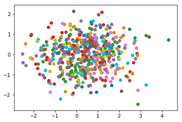

```python
z_dim = 2
vae = autoencoder.VAE(encoder_cnn, decoder_cnn, x0[0].size(), z_dim).to(device)
print(vae)

z, mu, log_sigma2 = vae.encode(x0)

test.assertSequenceEqual(z.shape, (1, z_dim))
test.assertTrue(z.shape == mu.shape == log_sigma2.shape)

print(f'mu(x0)={list(*mu.detach().cpu().numpy())}, sigma2(x0)={list(*torch.exp(log_sigma2).detach().cpu().numpy())}')

# Sample from q(Z|x)
N = 500
Z = torch.zeros(N, z_dim)
_, ax = plt.subplots()
with torch.no_grad():
    for i in range(500):
        Z[i], _, _ = vae.encode(x0)
        ax.scatter(*Z[i].cpu().numpy())

# Should be close to the above
print('sampled mu', torch.mean(Z, dim=0))
print('sampled sigma2', torch.var(Z, dim=0))
```

Let's now implement the full VAE Decoder, $\Psi _{\bb{\beta}}(\bb{z})$. It will work as follows:

1. Produce a feature vector $\tilde{\vec{h}}$ from the latent vector $\vec{z}$ using an affine transform.
2. Reconstruct an image $\tilde{\vec{x}}$ from $\tilde{\vec{h}}$.

**TODO**: Implement the `decode()` method in the `VAE` class within the `hw3/autoencoder.py` module. You'll also need to define your parameters in `__init__()`. You may need to also re-run the block above after you implement this.

```python
x0r = vae.decode(z)

test.assertSequenceEqual(x0r.shape, x0.shape)
```

Our model's `forward()` function will simply return `decode(encode(x))` as well as the calculated mean and log-variance of the posterior.

```python
x0r, mu, log_sigma2 = vae(x0)

test.assertSequenceEqual(x0r.shape, x0.shape)
test.assertSequenceEqual(mu.shape, (1, z_dim))
test.assertSequenceEqual(log_sigma2.shape, (1, z_dim))
T.functional.to_pil_image(x0r[0].detach().cpu())
```

### Loss Implementation

In practice, since we're using SGD, we'll drop the expectation over $\bb{X}$ and instead sample an instance from the training set and compute a point-wise loss. Similarly, we'll drop the expectation over $\bb{Z}$ by sampling from $q_{\vec{\alpha}}(\bb{Z}|\bb{x})$. Additionally, because the KL divergence is between two Gaussian distributions, there is a closed-form expression for it. These points bring us to the following point-wise loss:

$$ \ell(\vec{\alpha},\vec{\beta};\bb{x}) = \frac{1}{\sigma^2} \left\| \bb{x}- \Psi _{\bb{\beta}}\left( \bb{\mu} _{\bb{\alpha}}(\bb{x}) + \bb{\Sigma}^{\frac{1}{2}} _{\bb{\alpha}}(\bb{x}) \bb{u} \right) \right\| _2^2 + \mathrm{tr}\,\bb{\Sigma} _{\bb{\alpha}}(\bb{x}) + \|\bb{\mu} _{\bb{\alpha}}(\bb{x})\|^2 _2 - d_z - \log\det \bb{\Sigma} _{\bb{\alpha}}(\bb{x}) $$

where $d_z$ is the dimension of the latent space. This pointwise loss is the quantity that we'll compute and minimize with gradient descent.

**TODO**: Implement the `vae_loss()` function in the `hw3/autoencoder.py` module.

```python
from hw3.autoencoder import vae_loss
torch.manual_seed(42)

def test_vae_loss():
    # Test data
    N, C, H, W = 10, 3, 64, 64
    z_dim = 32
    x  = torch.randn(N, C, H, W)*2 - 1
    xr = torch.randn(N, C, H, W)*2 - 1
    z_mu = torch.randn(N, z_dim)
    z_log_sigma2 = torch.randn(N, z_dim)
    x_sigma2 = 0.9

    loss, _, _ = vae_loss(x, xr, z_mu, z_log_sigma2, x_sigma2)

    test.assertAlmostEqual(loss.item(), 58.3234367, delta=1e-3)
    return loss

test_vae_loss()
```

```
tensor(58.3234)
```

### Sampling

The main advantage of a VAE is that it can by used as a generative model by sampling the latent space, since we optimize for a Normal prior $p(\bb{Z})$ in the loss function. Let's now implement this so that we can visualize how our model is doing when we train.

**TODO**: Implement the `sample()` method in the `VAE` class within the `hw3/autoencoder.py` module.

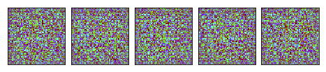

```python
samples = vae.sample(5)
_ = plot.tensors_as_images(samples)
```

### Training

Time to train!

**TODO**:

1. Implement the `VAETrainer` class in the `hw3/training.py` module. Make sure to implement the `checkpoints` feature of the `Trainer` class if you haven't done so already in Part 1.
2. Tweak the hyperparameters in the `part2_vae_hyperparam()` function within the `hw3/answers.py` module.

```python
import torch.optim as optim
from torch.utils.data import random_split
from torch.utils.data import DataLoader
from torch.nn import DataParallel
from hw3.training import VAETrainer
from hw3.answers import part2_vae_hyperparams

torch.manual_seed(42)

# Hyperparams
hp = part2_vae_hyperparams()
batch_size = hp['batch_size']
h_dim = hp['h_dim']
z_dim = hp['z_dim']
x_sigma2 = hp['x_sigma2']
learn_rate = hp['learn_rate']
betas = hp['betas']

# Data
split_lengths = [int(len(ds_gwb)*0.9), int(len(ds_gwb)*0.1)]
ds_train, ds_test = random_split(ds_gwb, split_lengths)
dl_train = DataLoader(ds_train, batch_size, shuffle=True)
dl_test  = DataLoader(ds_test,  batch_size, shuffle=True)
im_size = ds_train[0][0].shape

# Model
encoder = autoencoder.EncoderCNN(in_channels=im_size[0], out_channels=h_dim)
decoder = autoencoder.DecoderCNN(in_channels=h_dim, out_channels=im_size[0])
vae = autoencoder.VAE(encoder, decoder, im_size, z_dim)
vae_dp = DataParallel(vae).to(device)

# Optimizer
optimizer = optim.Adam(vae.parameters(), lr=learn_rate, betas=betas)

# Loss
def loss_fn(x, xr, z_mu, z_log_sigma2):
    return autoencoder.vae_loss(x, xr, z_mu, z_log_sigma2, x_sigma2)

# Trainer
trainer = VAETrainer(vae_dp, loss_fn, optimizer, device)
checkpoint_file = 'checkpoints/vae'
checkpoint_file_final = f'{checkpoint_file}_final'
if os.path.isfile(f'{checkpoint_file}.pt'):
    os.remove(f'{checkpoint_file}.pt')

# Show model and hypers
print(vae)
print(hp)
```

```
VAE(
  (features_encoder): EncoderCNN(
    (cnn): Sequential(
      (0): Conv2d(3, 180, kernel_size=(6, 6), stride=(2, 2), padding=(1, 1))
      (1): ReLU()
      (2): BatchNorm2d(180, eps=1e-05, momentum=0.1, affine=True, track_running_stats=True)
      (3): Conv2d(180, 360, kernel_size=(3, 3), stride=(2, 2))
      (4): BatchNorm2d(360, eps=1e-05, momentum=0.1, affine=True, track_running_stats=True)
      (5): ReLU()
      (6): Conv2d(360, 540, kernel_size=(3, 3), stride=(3, 3))
      (7): BatchNorm2d(540, eps=1e-05, momentum=0.1, affine=True, track_running_stats=True)
      (8): ReLU()
      (9): Conv2d(540, 50, kernel_size=(2, 2), stride=(1, 1))
      (10): BatchNorm2d(50, eps=1e-05, momentum=0.1, affine=True, track_running_stats=True)
      (11): ReLU()
    )
  )
  (features_decoder): DecoderCNN(
    (cnn): Sequential(
      (0): ReLU()
      (1): BatchNorm2d(50, eps=1e-05, momentum=0.1, affine=True, track_running_stats=True)
      (2): ConvTranspose2d(50, 540, kernel_size=(2, 2), stride=(1, 1))
      (3): ReLU()
      (4): BatchNorm2d(540, eps=1e-05, momentum=0.1, affine=True, track_running_stats=True)
      (5): ConvTranspose2d(540, 360, kernel_size=(3, 3), stride=(3, 3))
      (6): ReLU()
      (7): BatchNorm2d(360, eps=1e-05, momentum=0.1, affine=True, track_running_stats=True)
      (8): ConvTranspose2d(360, 180, kernel_size=(3, 3), stride=(2, 2))
      (9): ReLU()
      (10): BatchNorm2d(180, eps=1e-05, momentum=0.1, affine=True, track_running_stats=True)
      (11): ConvTranspose2d(180, 3, kernel_size=(6, 6), stride=(2, 2), padding=(1, 1))
      (12): BatchNorm2d(3, eps=1e-05, momentum=0.1, affine=True, track_running_stats=True)
    )
  )
  (W_hmu): Linear(in_features=800, out_features=15, bias=True)
  (W_hlsig2): Linear(in_features=800, out_features=15, bias=True)
  (W_zh): Linear(in_features=15, out_features=800, bias=True)
)
{'batch_size': 10, 'h_dim': 50, 'z_dim': 15, 'x_sigma2': 0.007, 'learn_rate': 0.0001, 'betas': (0.75, 0.75)}
```

**TODO**:

1. Run the following block to train. It will sample some images from your model every few epochs so you can see the progress.
2. When you're satisfied with your results, rename the checkpoints file by adding `_final`. When you run the `main.py` script to generate your submission, the final checkpoints file will be loaded instead of running training.

```
--- EPOCH 1/200 ---
train_batch (Avg. Loss 50.313, Accuracy 0.2): 100%|██████████| 48/48 [00:01<00:00, 38.59it/s]
test_batch (Avg. Loss 44.473, Accuracy 0.3): 100%|██████████| 6/6 [00:00<00:00, 66.56it/s]
*** Saved checkpoint checkpoints/vae.pt at epoch 1
```

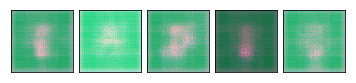

```
*** Saved checkpoint checkpoints/vae.pt at epoch 2
*** Saved checkpoint checkpoints/vae.pt at epoch 3
*** Saved checkpoint checkpoints/vae.pt at epoch 4
*** Saved checkpoint checkpoints/vae.pt at epoch 5
*** Saved checkpoint checkpoints/vae.pt at epoch 7
*** Saved checkpoint checkpoints/vae.pt at epoch 10
--- EPOCH 11/200 ---
train_batch (Avg. Loss 39.300, Accuracy 0.3): 100%|██████████| 48/48 [00:01<00:00, 38.40it/s]
test_batch (Avg. Loss 37.662, Accuracy 0.3): 100%|██████████| 6/6 [00:00<00:00, 66.57it/s]
```

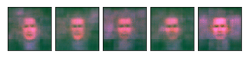

```
*** Saved checkpoint checkpoints/vae.pt at epoch 12
*** Saved checkpoint checkpoints/vae.pt at epoch 15
*** Saved checkpoint checkpoints/vae.pt at epoch 19
--- EPOCH 21/200 ---
train_batch (Avg. Loss 36.111, Accuracy 0.3): 100%|██████████| 48/48 [00:01<00:00, 38.29it/s]
test_batch (Avg. Loss 35.783, Accuracy 0.3): 100%|██████████| 6/6 [00:00<00:00, 65.45it/s]
```

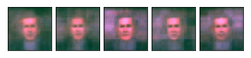

```
*** Saved checkpoint checkpoints/vae.pt at epoch 22
*** Saved checkpoint checkpoints/vae.pt at epoch 23
*** Saved checkpoint checkpoints/vae.pt at epoch 27
*** Saved checkpoint checkpoints/vae.pt at epoch 29
--- EPOCH 31/200 ---
train_batch (Avg. Loss 34.224, Accuracy 0.3): 100%|██████████| 48/48 [00:01<00:00, 38.05it/s]
test_batch (Avg. Loss 33.843, Accuracy 0.4): 100%|██████████| 6/6 [00:00<00:00, 65.22it/s]
*** Saved checkpoint checkpoints/vae.pt at epoch 31
```

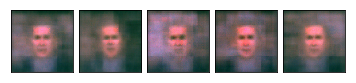

```
*** Saved checkpoint checkpoints/vae.pt at epoch 32
*** Saved checkpoint checkpoints/vae.pt at epoch 33
*** Saved checkpoint checkpoints/vae.pt at epoch 34
*** Saved checkpoint checkpoints/vae.pt at epoch 38
--- EPOCH 41/200 ---
train_batch (Avg. Loss 32.007, Accuracy 0.3): 100%|██████████| 48/48 [00:01<00:00, 38.65it/s]
test_batch (Avg. Loss 33.431, Accuracy 0.4): 100%|██████████| 6/6 [00:00<00:00, 67.06it/s]
```

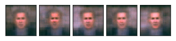

```
*** Saved checkpoint checkpoints/vae.pt at epoch 44
*** Saved checkpoint checkpoints/vae.pt at epoch 49
--- EPOCH 51/200 ---
train_batch (Avg. Loss 31.130, Accuracy 0.3): 100%|██████████| 48/48 [00:01<00:00, 38.37it/s]
test_batch (Avg. Loss 32.384, Accuracy 0.4): 100%|██████████| 6/6 [00:00<00:00, 65.62it/s]
```

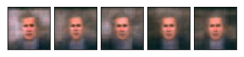

```
*** Saved checkpoint checkpoints/vae.pt at epoch 54
*** Saved checkpoint checkpoints/vae.pt at epoch 60
--- EPOCH 61/200 ---
train_batch (Avg. Loss 30.688, Accuracy 0.4): 100%|██████████| 48/48 [00:01<00:00, 38.29it/s]
test_batch (Avg. Loss 32.188, Accuracy 0.4): 100%|██████████| 6/6 [00:00<00:00, 66.07it/s]
```

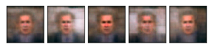

```
--- EPOCH 71/200 ---
train_batch (Avg. Loss 30.139, Accuracy 0.4): 100%|██████████| 48/48 [00:01<00:00, 37.63it/s]
test_batch (Avg. Loss 31.865, Accuracy 0.4): 100%|██████████| 6/6 [00:00<00:00, 60.25it/s]
```

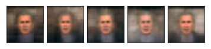

```
*** Saved checkpoint checkpoints/vae.pt at epoch 74
--- EPOCH 81/200 ---
train_batch (Avg. Loss 29.361, Accuracy 0.4): 100%|██████████| 48/48 [00:01<00:00, 38.35it/s]
test_batch (Avg. Loss 30.185, Accuracy 0.4): 100%|██████████| 6/6 [00:00<00:00, 66.46it/s]
```

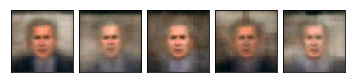

```
--- EPOCH 91/200 ---
train_batch (Avg. Loss 29.079, Accuracy 0.4): 100%|██████████| 48/48 [00:01<00:00, 35.86it/s]
test_batch (Avg. Loss 29.678, Accuracy 0.4): 100%|██████████| 6/6 [00:00<00:00, 64.00it/s]
```

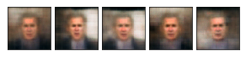

```
--- EPOCH 101/200 ---
train_batch (Avg. Loss 28.766, Accuracy 0.4): 100%|██████████| 48/48 [00:01<00:00, 38.66it/s]
test_batch (Avg. Loss 30.031, Accuracy 0.4): 100%|██████████| 6/6 [00:00<00:00, 66.48it/s]
```

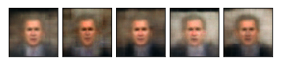

```
*** Saved checkpoint checkpoints/vae.pt at epoch 103
*** Saved checkpoint checkpoints/vae.pt at epoch 106
--- EPOCH 111/200 ---
train_batch (Avg. Loss 28.573, Accuracy 0.4): 100%|██████████| 48/48 [00:01<00:00, 38.65it/s]
test_batch (Avg. Loss 28.328, Accuracy 0.5): 100%|██████████| 6/6 [00:00<00:00, 66.86it/s]
*** Saved checkpoint checkpoints/vae.pt at epoch 111
```

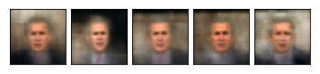

```
--- EPOCH 121/200 ---
train_batch (Avg. Loss 28.247, Accuracy 0.4): 100%|██████████| 48/48 [00:01<00:00, 38.48it/s]
test_batch (Avg. Loss 28.736, Accuracy 0.4): 100%|██████████| 6/6 [00:00<00:00, 66.83it/s]
```

[10 more figures not shown]

```python
import IPython.display

def post_epoch_fn(epoch, train_result, test_result, verbose):
    # Plot some samples if this is a verbose epoch
    if verbose:
        samples = vae.sample(n=5)
        fig, _ = plot.tensors_as_images(samples, figsize=(6,2))
        IPython.display.display(fig)
        plt.close(fig)

if False: # os.path.isfile(f'{checkpoint_file_final}.pt'):
    print(f'*** Loading final checkpoint file {checkpoint_file_final} instead of training')
    checkpoint_file = checkpoint_file_final
else:
    res = trainer.fit(dl_train, dl_test,
                      num_epochs=200, print_every=10,
                      checkpoints=checkpoint_file,
                      post_epoch_fn=post_epoch_fn)

# Plot images from best model
saved_state = torch.load(f'{checkpoint_file}.pt', map_location=device)
vae_dp.load_state_dict(saved_state['model_state'])
print('*** Images Generated from best model:')
fig, _ = plot.tensors_as_images(vae_dp.module.sample(n=15), nrows=3, figsize=(6,6))
```

## Questions

**TODO** Answer the following questions. Write your answers in the appropriate variables in the module `hw3/answers.py`.

```python
from cs236605.answers import display_answer
import hw3.answers
```

### Question 1

What does the $\sigma^2$ hyperparameter (`x_sigma2` in the code) do? Explain the effect of low and high values.

```python
display_answer(hw3.answers.part2_q1)
```

[output not shown]

### Question 2

1. Explain the purpose of both parts of the VAE loss term - reconstruction loss and KL divergence loss.
2. How is the latent-space distribution affected by the KL loss term?
3. What's the benefit of this?

```python
display_answer(hw3.answers.part2_q2)
```

1. The first part of the loss, the reconstruction part, makes sure that the resulted images are similar the input images. The second part is based on the Kullback–Leibler divergence, it measures the similarity of one distribution to another. Minimization of the second part will result by closer distributions $p(Z|X), p(Z)$

2. The KL loss term makes the latent space distribution similar to the assumed gaussian distribution $p(Z).

3. The sampled instances will be close to the real samples.

$$ \newcommand{\mat}[1]{\boldsymbol {#1}} \newcommand{\mattr}[1]{\boldsymbol {#1}^\top} \newcommand{\matinv}[1]{\boldsymbol {#1}^{-1}} \newcommand{\vec}[1]{\boldsymbol {#1}} \newcommand{\vectr}[1]{\boldsymbol {#1}^\top} \newcommand{\rvar}[1]{\mathrm {#1}} \newcommand{\rvec}[1]{\boldsymbol{\mathrm{#1}}} \newcommand{\diag}{\mathop{\mathrm {diag}}} \newcommand{\set}[1]{\mathbb {#1}} \newcommand{\norm}[1]{\left\lVert#1\right\rVert} \newcommand{\pderiv}[2]{\frac{\partial #1}{\partial #2}} \newcommand{\bm}[1]{{\bf #1}} \newcommand{\bb}[1]{\bm{\mathrm{#1}}} $$

# Part 3: Generative Adversarial Networks

In this part we will implement and train a generative adversarial network and apply it to the task of image generation.

```python
import unittest
import os
import sys
import pathlib
import urllib
import shutil
import re
import zipfile

import numpy as np
import torch
import matplotlib.pyplot as plt

%load_ext autoreload
%autoreload 2

test = unittest.TestCase()
plt.rcParams.update({'font.size': 12})
device = torch.device('cuda' if torch.cuda.is_available() else 'cpu')
print('Using device:', device)
```

```
Using device: cuda
```

### Obtaining the dataset

We'll use the same data as in Part 2.

But again, to use a custom dataset, edit the `PART3_CUSTOM_DATA_URL` variable in `hw3/answers.py`.

```python
import cs236605.plot as plot
import cs236605.download
from hw3.answers import PART3_CUSTOM_DATA_URL as CUSTOM_DATA_URL

DATA_DIR = pathlib.Path.home().joinpath('.pytorch-datasets')
if CUSTOM_DATA_URL is None:
    DATA_URL = 'http://vis-www.cs.umass.edu/lfw/lfw-bush.zip'
else:
    DATA_URL = CUSTOM_DATA_URL

_, dataset_dir = cs236605.download.download_data(out_path=DATA_DIR, url=DATA_URL, extract=True, force=False)
```

```
File /home/asaf/.pytorch-datasets/lfw-bush.zip exists, skipping download.
Extracting /home/asaf/.pytorch-datasets/lfw-bush.zip...
Extracted 531 to /home/asaf/.pytorch-datasets/lfw/George_W_Bush
```

Create a `Dataset` object that will load the extraced images:

```python
import torchvision.transforms as T
from torchvision.datasets import ImageFolder

im_size = 64
tf = T.Compose([
    # Resize to constant spatial dimensions
    T.Resize((im_size, im_size)),
    # PIL.Image -> torch.Tensor
    T.ToTensor(),
    # Dynamic range [0,1] -> [-1, 1]
    T.Normalize(mean=(.5,.5,.5), std=(.5,.5,.5)),
])

ds_gwb = ImageFolder(os.path.dirname(dataset_dir), tf)
```

OK, let's see what we got. You can run the following block multiple times to display a random subset of images from the dataset.

```
Found 530 images in dataset folder.
```

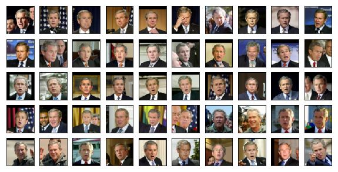

```python
_ = plot.dataset_first_n(ds_gwb, 50, figsize=(10,5), nrows=5)
print(f'Found {len(ds_gwb)} images in dataset folder.')
```

```python
x0, y0 = ds_gwb[0]
x0 = x0.unsqueeze(0).to(device)
print(x0.shape)

test.assertSequenceEqual(x0.shape, (1, 3, im_size, im_size))
```

```
torch.Size([1, 3, 64, 64])
```

## Generative Adversarial Nets (GANs)

GANs, first proposed in a [paper](https://arxiv.org/pdf/1406.2661.pdf) by Ian Goodfellow in 2014 are today arguably the most popular type of generative model. GANs are currently producing state of the art results in generative tasks over many different domains.

In a GAN model, two different neural networks compete against each other: A **generator** and a **discriminator**.

- The Generator, which we'll denote as $\Psi _{\bb{\gamma}} : \mathcal{U} \rightarrow \mathcal{X}$, maps a latent-space variable $\bb{u}\sim\mathcal{N}(\bb{0},\bb{I})$ to an instance-space variable $\bb{x}$ (e.g. an image). Thus a parametric evidence distribution $p_{\bb{\gamma}}(\bb{X})$ is generated, which we typically would like to be as close as possible to the real evidence distribution, $p(\bb{X})$.
- The Discriminator, $\Delta _{\bb{\delta}} : \mathcal{X} \rightarrow [0,1]$, is a network which, given an instance-space variable $\bb{x}$, returns the probability that $\bb{x}$ is real, i.e. that $\bb{x}$ was sampled from $p(\bb{X})$ and not $p_{\bb{\gamma}}(\bb{X})$.

[figure not shown]

### Training GANs

The generator is trained to generate "fake" instances which will maximally fool the discriminator into returning that they're real. Mathematically, the generator's parameters $\bb{\gamma}$ should be chosen such as to **maximize** the expression $$ \mathbb{E} _{\bb{z} \sim p(\bb{Z}) } \log (\Delta _{\bb{\delta}}(\Psi _{\bb{\gamma}} (\bb{z}) )). $$

The discriminator is trained to classify between real images, coming from the training set, and fake images generated by the generator. Mathematically, the discriminator's parameters $\bb{\delta}$ should be chosen such as to **maximize** the expression $$ \mathbb{E} _{\bb{x} \sim p(\bb{X}) } \log \Delta _{\bb{\delta}}(\bb{x}) \, + \, \mathbb{E} _{\bb{z} \sim p(\bb{Z}) } \log (1-\Delta _{\bb{\delta}}(\Psi _{\bb{\gamma}} (\bb{z}) )). $$

These two competing objectives can thus be expressed as the following min-max optimization: $$ \min _{\bb{\gamma}} \max _{\bb{\delta}} \, \mathbb{E} _{\bb{x} \sim p(\bb{X}) } \log \Delta _{\bb{\delta}}(\bb{x}) \, + \, \mathbb{E} _{\bb{z} \sim p(\bb{Z}) } \log (1-\Delta _{\bb{\delta}}(\Psi _{\bb{\gamma}} (\bb{z}) )). $$

A key insight into GANs is that we can interpret the above maximum as the loss with respect to $\bb{\gamma}$:

$$ L({\bb{\gamma}}) = \max _{\bb{\delta}} \, \mathbb{E} _{\bb{x} \sim p(\bb{X}) } \log \Delta _{\bb{\delta}}(\bb{x}) \, + \, \mathbb{E} _{\bb{z} \sim p(\bb{Z}) } \log (1-\Delta _{\bb{\delta}}(\Psi _{\bb{\gamma}} (\bb{z}) )). $$

This means that the generator's loss function trains together with the generator itself in an adversarial manner. In contrast, when training our VAE we used a fixed L2 norm as a data loss term.

### Model Implementation

We'll now implement a Deep Convolutional GAN (DCGAN) model. See the DCGAN [paper](https://arxiv.org/pdf/1511.06434.pdf) for architecture ideas and tips for training.

**TODO**: Implement the `Discriminator` class in the `hw3/gan.py` module. If you wish you can reuse the `EncoderCNN` class from the VAE model as the first part of the Discriminator.

```python
import hw3.gan as gan

dsc = gan.Discriminator(in_size=x0[0].shape).to(device)
print(dsc)

d0 = dsc(x0)
print(d0.shape)

test.assertSequenceEqual(d0.shape, (1,1))
```

```
Discriminator(
  (main): Sequential(
    (0): Conv2d(3, 64, kernel_size=(4, 4), stride=(2, 2), padding=(1, 1), bias=False)
    (1): LeakyReLU(negative_slope=0.2, inplace)
    (2): Conv2d(64, 128, kernel_size=(4, 4), stride=(2, 2), padding=(1, 1), bias=False)
    (3): BatchNorm2d(128, eps=1e-05, momentum=0.1, affine=True, track_running_stats=True)
    (4): LeakyReLU(negative_slope=0.2, inplace)
    (5): Conv2d(128, 256, kernel_size=(4, 4), stride=(2, 2), padding=(1, 1), bias=False)
    (6): BatchNorm2d(256, eps=1e-05, momentum=0.1, affine=True, track_running_stats=True)
    (7): LeakyReLU(negative_slope=0.2, inplace)
    (8): Conv2d(256, 512, kernel_size=(4, 4), stride=(2, 2), padding=(1, 1), bias=False)
    (9): BatchNorm2d(512, eps=1e-05, momentum=0.1, affine=True, track_running_stats=True)
    (10): LeakyReLU(negative_slope=0.2, inplace)
    (11): Conv2d(512, 1, kernel_size=(4, 4), stride=(1, 1), bias=False)
    (12): Sigmoid()
  )
)
torch.Size([1, 1])
```

**TODO**: Implement the `Generator` class in the `hw3/gan.py` module. If you wish you can reuse the `DecoderCNN` class from the VAE model as the last part of the Generator.

```python
z_dim = 128
gen = gan.Generator(z_dim, 4).to(device)
print(gen)

z = torch.randn(1, z_dim).to(device)
xr = gen(z)
print(xr.shape)

test.assertSequenceEqual(x0.shape, xr.shape)
```

```
Generator(
  (main): Sequential(
    (0): ConvTranspose2d(128, 512, kernel_size=(4, 4), stride=(1, 1), bias=False)
    (1): BatchNorm2d(512, eps=1e-05, momentum=0.1, affine=True, track_running_stats=True)
    (2): ReLU(inplace)
    (3): ConvTranspose2d(512, 256, kernel_size=(4, 4), stride=(2, 2), padding=(1, 1), bias=False)
    (4): BatchNorm2d(256, eps=1e-05, momentum=0.1, affine=True, track_running_stats=True)
    (5): ReLU(inplace)
    (6): ConvTranspose2d(256, 128, kernel_size=(4, 4), stride=(2, 2), padding=(1, 1), bias=False)
    (7): BatchNorm2d(128, eps=1e-05, momentum=0.1, affine=True, track_running_stats=True)
    (8): ReLU(inplace)
    (9): ConvTranspose2d(128, 64, kernel_size=(4, 4), stride=(2, 2), padding=(1, 1), bias=False)
    (10): BatchNorm2d(64, eps=1e-05, momentum=0.1, affine=True, track_running_stats=True)
    (11): ReLU(inplace)
    (12): ConvTranspose2d(64, 3, kernel_size=(4, 4), stride=(2, 2), padding=(1, 1), bias=False)
    (13): Tanh()
  )
)
torch.Size([1, 3, 64, 64])
```

### Loss Implementation

We're using the Discriminator twice in this expression; once to classify data from the real data distribution and once again to classify generated data. Therefore our loss should be computed based on these two terms. Notice that since the discriminator returns a probability, we can formulate the above as two cross-entropy losses.

GANs are notoriously diffucult to train. One common trick for improving GAN stability during training is to make the classification labels noisy for the discriminator. This can be seen as a form of regularization, to help prevent the discriminator from overfitting.

We'll incorporate this idea into our loss function. Instead of labels being equal to 0 or 1, we'll make them "fuzzy", i.e. random numbers in the ranges $[0\pm\epsilon]$ and $[1\pm\epsilon]$.

**TODO**: Implement the `discriminator_loss_fn()` function in the `hw3/gan.py` module.

```python
from hw3.gan import discriminator_loss_fn
torch.manual_seed(42)

y_data = torch.rand(10) * 10
y_generated = torch.rand(10) * 10

loss = discriminator_loss_fn(y_data, y_generated, data_label=1, label_noise=0.3)
print(loss)

test.assertAlmostEqual(loss.item(), 6.4808731, delta=1e-5)
```

```
tensor(6.4809)
```

Similarly, the generator's parameters $\bb{\gamma}$ should **minimize** the expression $$ -\mathbb{E} _{\bb{z} \sim p(\bb{Z}) } \log (\Delta _{\bb{\delta}}(\Psi _{\bb{\gamma}} (\bb{z}) )) $$

which can also be seen as a cross-entropy term.

**TODO**: Implement the `generator_loss_fn()` function in the `hw3/gan.py` module.

```python
from hw3.gan import generator_loss_fn
torch.manual_seed(42)

y_generated = torch.rand(20) * 10

loss = generator_loss_fn(y_generated, data_label=1)
print(loss)

test.assertAlmostEqual(loss.item(), 0.0222969, delta=1e-3)
```

```
tensor(0.0223)
```

### Sampling

Sampling from a GAN is straightforward, since it learns to generate data from an isotropic Gaussian latent space distribution.

There is an important nuance however. Sampling is required during the process of training the GAN, since we generate fake images to show the discriminator. As you'll seen in the next section, in some cases we'll need our samples to have gradients (i.e., to be part of the Generator's computation graph).

**TODO**: Implement the `sample()` method in the `Generator` class within the `hw3/gan.py` module.

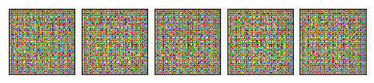

```python
samples = gen.sample(5, with_grad=False)
test.assertSequenceEqual(samples.shape, (5, *x0.shape[1:]))
test.assertIsNone(samples.grad_fn)
_ = plot.tensors_as_images(samples.cpu())

samples = gen.sample(5, with_grad=True)
test.assertSequenceEqual(samples.shape, (5, *x0.shape[1:]))
test.assertIsNotNone(samples.grad_fn)
```

### Training

Training GANs is a bit different since we need to train two models simultaneously, each with it's own separate loss function and optimizer. We'll implement the training logic as a function that handles one batch of data and updates both the discriminator and the generator based on it.

As mentioned above, GANs are considered hard to train. To get some ideas and tips you can see this [paper](https://arxiv.org/pdf/1606.03498.pdf), this list of ["GAN hacks"](https://github.com/soumith/ganhacks) or just do it the hard way :)

**TODO**:

1. Implement the `train_batch` function in the `hw3/gan.py` module.
2. Tweak the hyperparameters in the `part3_gan_hyperparam()` function within the `hw3/answers.py` module.

```python
import torch.optim as optim
from torch.utils.data import DataLoader
from hw3.answers import part3_gan_hyperparams

torch.manual_seed(42)

# Hyperparams
hp = part3_gan_hyperparams()
batch_size = hp['batch_size']
z_dim = hp['z_dim']

# Data
dl_train = DataLoader(ds_gwb, batch_size, shuffle=True)
im_size = ds_gwb[0][0].shape

# Model
dsc = gan.Discriminator(im_size).to(device)
gen = gan.Generator(z_dim, featuremap_size=4).to(device)

# Optimizer
def create_optimizer(model_params, opt_params):
    opt_params = opt_params.copy()
    optimizer_type = opt_params['type']
    opt_params.pop('type')
    return optim.__dict__[optimizer_type](model_params, **opt_params)
dsc_optimizer = create_optimizer(dsc.parameters(), hp['discriminator_optimizer'])
gen_optimizer = create_optimizer(gen.parameters(), hp['generator_optimizer'])

# Loss
def dsc_loss_fn(y_data, y_generated):
    return gan.discriminator_loss_fn(y_data, y_generated, hp['data_label'], hp['label_noise'])

def gen_loss_fn(y_generated):
    return gan.generator_loss_fn(y_generated, hp['data_label'])

# Training
checkpoint_file = 'checkpoints/gan'
checkpoint_file_final = f'{checkpoint_file}_final'
if os.path.isfile(f'{checkpoint_file}.pt'):
    os.remove(f'{checkpoint_file}.pt')

# Show hypers
print(hp)
```

```
{'batch_size': 8, 'z_dim': 100, 'data_label': 1, 'label_noise': 0.3, 'discriminator_optimizer': {'type': 'SGD', 'lr': 0.075}, 'generator_optimizer': {'type': 'Adam', 'lr': 0.0002}}
```

**TODO**:

1. Run the following block to train. It will sample some images from your model every few epochs so you can see the progress.
2. When you're satisfied with your results, rename the checkpoints file by adding `_final`. When you run the `main.py` script to generate your submission, the final checkpoints file will be loaded instead of running training.

```python
import IPython.display
import tqdm
from hw3.gan import train_batch

num_epochs = 100

if os.path.isfile(f'{checkpoint_file_final}.pt'):
    print(f'*** Loading final checkpoint file {checkpoint_file_final} instead of training')
    num_epochs = 0
    gen = torch.load(f'{checkpoint_file_final}.pt', map_location=device)
    checkpoint_file = checkpoint_file_final

for epoch_idx in range(num_epochs):
    # We'll accumulate batch losses and show an average once per epoch.
    dsc_losses = []
    gen_losses = []
    print(f'--- EPOCH {epoch_idx+1}/{num_epochs} ---')

    with tqdm.tqdm(total=len(dl_train.batch_sampler), file=sys.stdout) as pbar:
        for batch_idx, (x_data, _) in enumerate(dl_train):
            x_data = x_data.to(device)
            dsc_loss, gen_loss = train_batch(
                dsc, gen,
                dsc_loss_fn, gen_loss_fn,
                dsc_optimizer, gen_optimizer,
                x_data)
            dsc_losses.append(dsc_loss)
            gen_losses.append(gen_loss)
            pbar.update()

    dsc_avg_loss, gen_avg_loss = np.mean(dsc_losses), np.mean(gen_losses)
    print(f'Discriminator loss: {dsc_avg_loss}')
    print(f'Generator loss:     {gen_avg_loss}')

    samples = gen.sample(5, with_grad=False)
    if not(epoch_idx % 10):
        fig, _ = plot.tensors_as_images(samples.cpu(), figsize=(6,2))
        IPython.display.display(fig)
        plt.close(fig)
```

```
*** Loading final checkpoint file checkpoints/gan_final instead of training
```

```
*** Images Generated from best model:
```

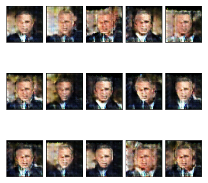

```python
# Plot images from best or last model
if os.path.isfile(f'{checkpoint_file}.pt'):
    gen = torch.load(f'{checkpoint_file}.pt', map_location=device)
print('*** Images Generated from best model:')
samples = gen.sample(n=15, with_grad=False).cpu()
fig, _ = plot.tensors_as_images(samples, nrows=3, figsize=(6,6))
```

## Questions

**TODO** Answer the following questions. Write your answers in the appropriate variables in the module `hw3/answers.py`.

```python
from cs236605.answers import display_answer
import hw3.answers
```

### Question 1

Explain in detail why during training we sometimes need to maintain gradients when sampling from the GAN, and other times we don't. When are they maintained and why? When are they discarded and why?

```python
display_answer(hw3.answers.part3_q1)
```

**Your answer:** The gradients from the GAN are neede to train two networks. The first - the discriminator - has its own parameters, loss and parameter's gradients. The second - the generator - has its loss calculated according to the discriminator performence. Thus this gradient of its parameters has to connect to it. We implement this connection by calculating the gradients of the generator's parameters so that the loss of the discriminator will be as high as possible - according to the negetive form of the discriminator gradients.

### Question 2

1. When training a GAN to generate images, should we decide to stop training solely based on the fact that the Generator loss is below some threshold? Why or why not?
2. What does it mean if the discriminator loss remains at a constant value while the generator loss decreases?

```python
display_answer(hw3.answers.part3_q2)
```

**Your answer:**

1. No, it is possible that the discriminator will improve thus, resulting with an improvement of the generator (although it might lead to a bigger loss of the generator).

2. When the discriminator loss remains at a constant value while the generator loss decreases, it is possible that the descriminator improves in identifying the real data samples while worsen in indentifying the fake samples.

### Question 3

Compare the results you got when generating images with the VAE to the GAN results. What's the main difference and what's causing it?

```python
display_answer(hw3.answers.part3_q3)
```

**Your answer:**

1. The first difference is in the quality of the generated images. The quality of the data generated from VAE is much better. This might be a result of more suitable choosing of hyperparameters but GANs are known to be harder to train.

2. The deviation of the data generated from GAN is higher.  
   Again we can say that it is the result of hyperparameters choosing, but the Generator did not get any image as an input and the train was solely based on the descriminator loss. This might lead to a more "creative" model.